# individual1

Sam Shifflett

Feburary 28, 2019

```r
install.packages("productplots")
data(happy, package="productplots")
head(happy)
```

```
##   id         happy year age    sex       marital         degree
## 1  1 not too happy 1972  23 female never married       bachelor
## 2  2 not too happy 1972  70   male       married lt high school
## 3  3  pretty happy 1972  48 female       married    high school
## 4  4 not too happy 1972  27 female       married       bachelor
## 5  5  pretty happy 1972  61 female       married    high school
## 6  6  pretty happy 1972  26   male never married    high school
##         finrela    health wtssall
## 1       average      good  0.4446
## 2 above average      fair  0.8893
## 3       average excellent  0.8893
## 4       average      good  0.8893
## 5 above average      good  0.8893
## 6 above average      good  0.4446
```

```r
HAPPY <- readRDS("HAPPY.rds")
```

finrela: income level for family wtssall: weight of the variables

Part 1: (1)

```r
head(HAPPY)
```

```
##           HAPPY YEAR AGE    SEX       MARITAL         DEGREE       FINRELA
## 1 NOT TOO HAPPY 1972  23 FEMALE NEVER MARRIED       BACHELOR       AVERAGE
## 2 NOT TOO HAPPY 1972  70   MALE       MARRIED LT HIGH SCHOOL ABOVE AVERAGE
## 3  PRETTY HAPPY 1972  48 FEMALE       MARRIED    HIGH SCHOOL       AVERAGE
## 4 NOT TOO HAPPY 1972  27 FEMALE       MARRIED       BACHELOR       AVERAGE
## 5  PRETTY HAPPY 1972  61 FEMALE       MARRIED    HIGH SCHOOL ABOVE AVERAGE
## 6  PRETTY HAPPY 1972  26   MALE NEVER MARRIED    HIGH SCHOOL ABOVE AVERAGE
##      HEALTH WTSSALL          PARTYID POLVIEWS
## 1      GOOD  0.4446     IND,NEAR DEM      IAP
## 2      FAIR  0.8893 NOT STR DEMOCRAT      IAP
## 3 EXCELLENT  0.8893      INDEPENDENT      IAP
## 4      GOOD  0.8893 NOT STR DEMOCRAT      IAP
## 5      GOOD  0.8893  STRONG DEMOCRAT      IAP
## 6      GOOD  0.4446     IND,NEAR DEM      IAP
```

```r
HAPPY[HAPPY == "IAP" | HAPPY == "DK" | HAPPY == "NA"] <- NA
```

```r
HAPPY[HAPPY == "89 OR OLDER"] <- 89
HAPPY[, "AGE"] <- sapply(HAPPY[, "AGE"], as.numeric)
sapply(HAPPY,class)
```

```
##       HAPPY        YEAR         AGE         SEX     MARITAL      DEGREE
## "character"   "integer"   "numeric" "character" "character" "character"
##     FINRELA      HEALTH     WTSSALL     PARTYID    POLVIEWS
## "character" "character"   "numeric" "character" "character"
```

```r
install.packages("tidyverse")
library("dplyr")
?dplyr::arrange
head(dplyr::arrange(HAPPY,HAPPY,SEX))
```

```
##           HAPPY YEAR AGE    SEX       MARITAL         DEGREE
## 1 NOT TOO HAPPY 1972  23 FEMALE NEVER MARRIED       BACHELOR
## 2 NOT TOO HAPPY 1972  27 FEMALE       MARRIED       BACHELOR
## 3 NOT TOO HAPPY 1972  49 FEMALE      DIVORCED LT HIGH SCHOOL
## 4 NOT TOO HAPPY 1972  63 FEMALE       MARRIED LT HIGH SCHOOL
## 5 NOT TOO HAPPY 1972  55 FEMALE       WIDOWED LT HIGH SCHOOL
## 6 NOT TOO HAPPY 1972  46 FEMALE     SEPARATED LT HIGH SCHOOL
##             FINRELA    HEALTH WTSSALL          PARTYID POLVIEWS
## 1           AVERAGE      GOOD  0.4446     IND,NEAR DEM     <NA>
## 2           AVERAGE      GOOD  0.8893 NOT STR DEMOCRAT     <NA>
## 3           AVERAGE      GOOD  1.3339 NOT STR DEMOCRAT     <NA>
## 4           AVERAGE EXCELLENT  0.8893      INDEPENDENT     <NA>
## 5           AVERAGE EXCELLENT  0.8893  STRONG DEMOCRAT     <NA>
## 6 FAR BELOW AVERAGE EXCELLENT  1.3339      INDEPENDENT     <NA>
```

Part 2: (1)—————————————————–

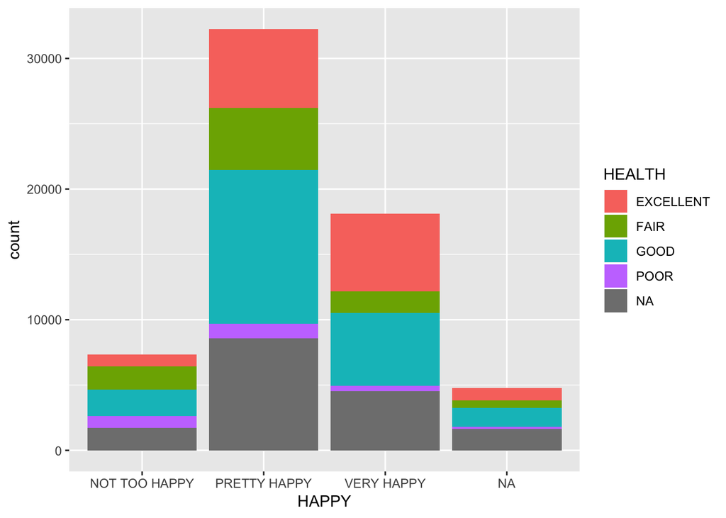

```r
library("ggplot2")
ggplot(data=HAPPY, aes(x=HAPPY)) + geom_bar(aes(fill=HEALTH))
```

You can see how the happiness ratings are distributed among the health of individuals. I found it kind of weird how people with poor health would say they are very happy, strange phenomenon. But the most even distribution is in the “not to happy” category. I think this may have to do with the fact that unhappiness doesn’t directly spur from health in general. Going to dig deeper to find what correlates more with “not to happy”.

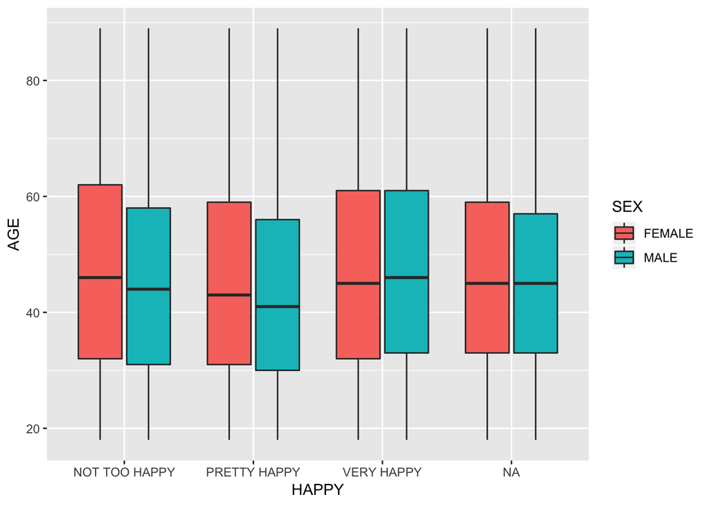

```r
ggplot(data=HAPPY, aes(x=HAPPY, y=AGE, na.rm=TRUE)) + geom_boxplot(aes(fill=SEX))
```

You can see in this plot that the average age of men is lower in the “not too happy” and “pretty happy” categories. But in the “very happy” category the average age of men is higher. It seems that a mans happiness increases as he gets older, while women tend to stay the same at each age.

(2)——————————————————

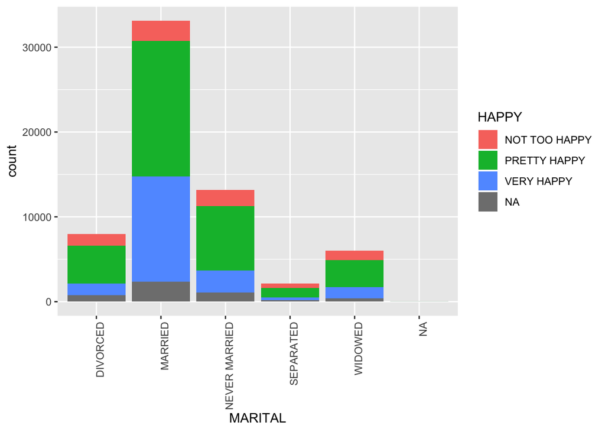

```r
ggplot(HAPPY, aes(x=MARITAL)) + geom_bar(aes(fill=HAPPY))+theme(axis.text.x = element_text(angle = 90, hjust = 1))
```

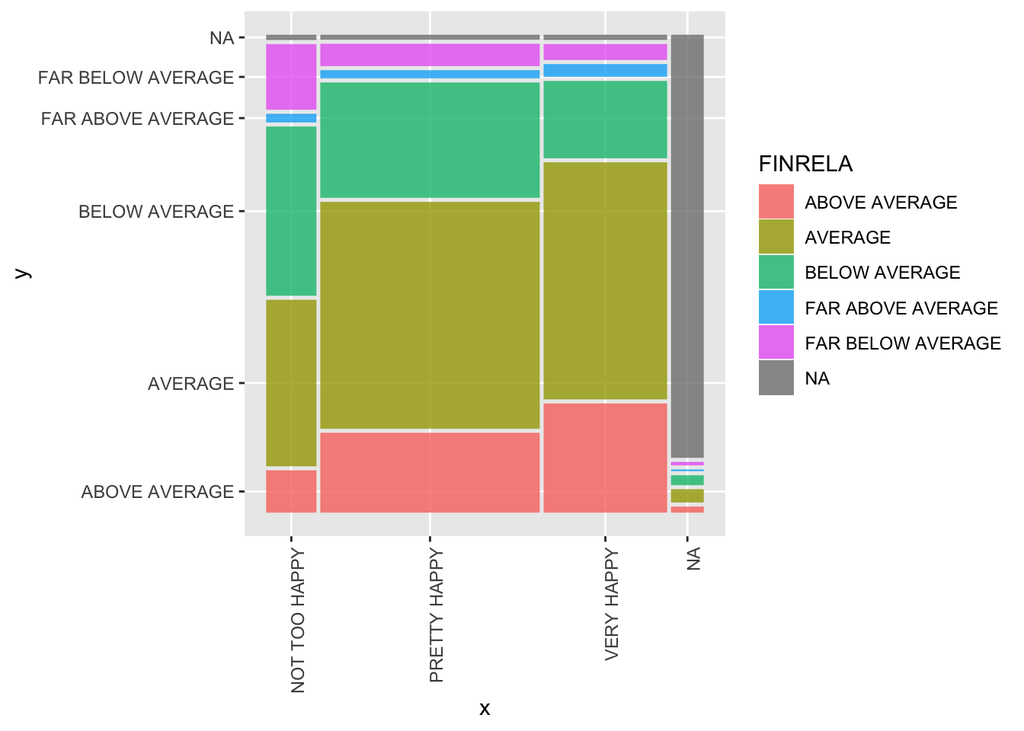

```r
install.packages("ggmosaic")
library("ggmosaic")
ggplot(HAPPY, aes(na.rm=TRUE)) + geom_mosaic(aes(x=product(HAPPY), fill=FINRELA, na.rm=TRUE))+theme(axis.text.x = element_text(angle = 90, hjust = 1))
```

You can see that the ‘very happy’ category has a large percentage of above average finacial relativity. Seems like the more money one has the happier he/she is. There is also are large percentage of people in the ‘not too happy’ who are far below average in finacial relativity.

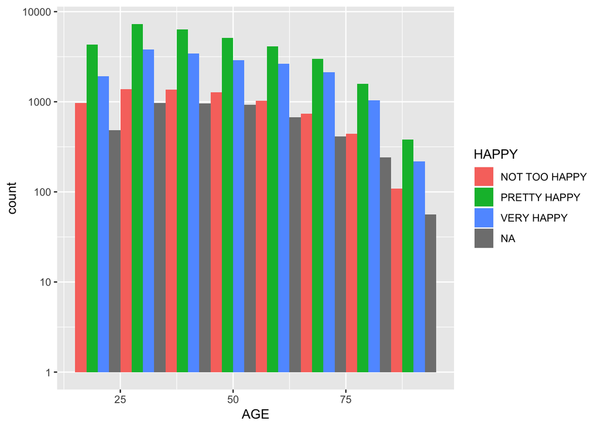

```r
library("ggplot2")
ggplot(HAPPY, aes(fill=HAPPY)) + geom_histogram(aes(x=AGE), binwidth=10, position="dodge") + scale_y_log10()
```

It seems that the peak of very happiness comes when you are around age 28.

3. Looking through the dataset we can see that many factor effect happiness overall. The factors that I looked at were age, finrela, and marriage. These variables seemed to have an effect on overall happiness. The age had a spike in happiness when the age was around 28. The finrela had a great increase in ‘very happy’ when the finrela was above average. Finally, the marriage status was largely distributed over the married category in ‘pretty happy’ and ‘very happy’.